# final project

Alana Flenoy

November 10, 2025

# Data

```r
head(chapters)
```

```
## # A tibble: 6 × 4
##   `Chapter ID` `Chapter Name`      `Movie ID` `Movie Chapter`
##          <dbl> <chr>                    <dbl>           <dbl>
## 1            1 Doorstep Delivery            1               1
## 2            2 The Vanishing Glass          1               2
## 3            3 Letters from No One          1               3
## 4            4 Keeper of the Keys           1               4
## 5            5 Diagon Alley                 1               5
## 6            6 Gringotts                    1               6
```

```r
head(movies)
```

```
## # A tibble: 6 × 6
##   `Movie ID` `Movie Title`            `Release Year` Runtime Budget `Box Office`
##        <dbl> <chr>                             <dbl>   <dbl> <chr>  <chr>
## 1          1 Harry Potter and the Ph…           2001     152 $125,… $1,002,000,…
## 2          2 Harry Potter and the Ch…           2002     161 $100,… $880,300,000
## 3          3 Harry Potter and the Pr…           2004     142 $130,… $796,700,000
## 4          4 Harry Potter and the Go…           2005     157 $150,… $896,400,000
## 5          5 Harry Potter and the Or…           2007     138 $150,… $942,000,000
## 6          6 Harry Potter and the Ha…           2009     153 $250,… $943,200,000
```

```r
head(spells)
```

```
## # A tibble: 6 × 7
##   `Spell ID` Incantation  `Spell Name` Effect Light Type  Offensive or Defensi…¹
##        <dbl> <chr>        <chr>        <chr>  <chr> <chr> <chr>
## 1          1 Accio        Summoning C… "Summ… <NA>  Charm Neither
## 2          2 Aguamenti    Water-Makin… "Conj… Icy … Charm Neither
## 3          3 Alarte Asce… Launch an o… "Rock… Red   Spell Offensive
## 4          4 Alohomora    Unlocking C… "Unlo… Blue  Charm Neither
## 5          5 Arania Exum… Spider repe… "Repe… Blue  Spell Offensive
## 6          6 Arresto Mom… Slowing Cha… "Slow… <NA>  Charm Defensive
## # ℹ abbreviated name: ¹`Offensive or Defensive`
```

```r
head(places)
```

```
## # A tibble: 6 × 3
##   `Place ID` `Place Name`             `Place Category`
##        <dbl> <chr>                    <chr>
## 1          1 Flourish & Blotts        Diagon Alley
## 2          2 Gringotts Wizarding Bank Diagon Alley
## 3          3 Knockturn Alley          Diagon Alley
## 4          4 Ollivanders              Diagon Alley
## 5          5 The Leaky Cauldron       Diagon Alley
## 6          6 Weasleys' Wizard Wheezes Diagon Alley
```

```r
head(characters)
```

```
## # A tibble: 6 × 17
##      Id Name   Gender Job   House `Wand Length` `Wand Wood` `Wand Core` Patronus
##   <dbl> <chr>  <chr>  <chr> <chr> <chr>         <chr>       <chr>       <chr>
## 1     1 Harry… male   Stud… Gryf… "11\""        Holly       Phoenix Fe… Stag
## 2     2 Ronal… male   Stud… Gryf… "12\""        Ash         Unicorn Ta… Jack Ru…
## 3     3 Hermi… female Stud… Gryf… "10.75\""     Vine        Dragon Hea… Otter
## 4     4 Albus… male   Head… Gryf… "15\""        Elder       Thestral T… Phoenix
## 5     5 Rubeu… male   Keep… Gryf… "16\""        Oak         Unknown     None
## 6     6 Nevil… male   Stud… Gryf… "13\""        Cherry      Unicorn Ta… Non-cor…
## # ℹ 8 more variables: Species <chr>, `Blood status` <chr>, `Hair colour` <chr>,
## #   `Eye colour` <chr>, Loyalty <chr>, Skills <chr>, Birth <chr>, Death <chr>
```

```r
head(dialogue)
```

```
## # A tibble: 6 × 5
##   `Dialogue ID` `Chapter ID` `Place ID` `Character ID` Dialogue
##           <dbl>        <dbl>      <dbl>          <dbl> <chr>
## 1             1            1          8              4 I should have known that…
## 2             2            1          8              7 Good evening, Professor …
## 3             3            1          8              4 I'm afraid so, Professor…
## 4             4            1          8              7 And the boy?
## 5             5            1          8              4 Hagrid is bringing him.
## 6             6            1          8              7 Do you think it wise to …
```

```r
head(creatures)
```

```
## # A tibble: 6 × 10
##   species `eye color` `skin color` hair or feather colo…¹ related to or resemb…²
##   <chr>   <chr>       <chr>        <chr>                  <chr>
## 1 Acroma… black       none         jet-black              spider
## 2 Ashwin… red         pale-grey    none                   snake
## 3 Augurey blue        none         greenish-black         bird
## 4 Basili… yellow      green        none                   snake, chicken, toad
## 5 Billyw… grey        bright blue  none                   bug
## 6 Blast-… none        pale         none                   bug
## # ℹ abbreviated names: ¹`hair or feather color`, ²`related to or resembles`
## # ℹ 5 more variables: `length of adult` <chr>, mortality <chr>, status <chr>,
## #   `ministry of magic classification` <chr>, `native to` <chr>
```

# Introduction

Harry Potter is one of the most popular movie franchises of all time. The Harry Potter world captivates its audience and leaves them with a sense of wonder and bewilderment. The data being analyzed will cover the characters, spells, places and dialogue within the books and movies, as well as the results of the movies shown through the budget and box office for each movie.

# Questions

- What percentage of gender, species, is in each house and school
- How often does each character’s name comes up in the dialogue?
- What percentage of characters are in each house and/or school?
- What is the most and least common wand type and how rare is the wand core?
- How much of each species there is?
- What are the most common and uncommon patronuses?
- What are the percentages of blood status in each house and school?

# Key Terms

## Spells

### Charm, Jinx, Spell, or Curse

- charm: a spell that adds properties to an object or person without changing its fundamental nature
- jinx: a minor type of dark magic that causes inconvenience or mild harm to the target
- spell: a command that uses a specific incantation and wand movement to produce a magical effect
- curse: a command that uses a specific incantation and wand movement to produce a magical effect
- offensive: are used to attack or harm an opponent
- defensive: are used to protect against attacks

## Creatures

### Mortality

- extant: still in existence
- mortal: able to die
- immortal: not able to die
- amortal: immune to aging and disease but not to catastrophic physical harm, or a state of not being alive or dead

### Ministry of Magic Classification

- x creatures: harmless to humans
- xx creatures: harmless and could be domesticated
- xxx creatures: should be no trouble to competent wizards
- xxxx creatures: dangerous and require special knowledge, only trained wizards should handle them, endangered or just too difficult to capture, rather than being dangerous.
- xxxxx creatures: are known wizard killers, are impossible to train or domesticate.

# House Distribution

## How many characters are in which Hogwarts house? (bar chart)

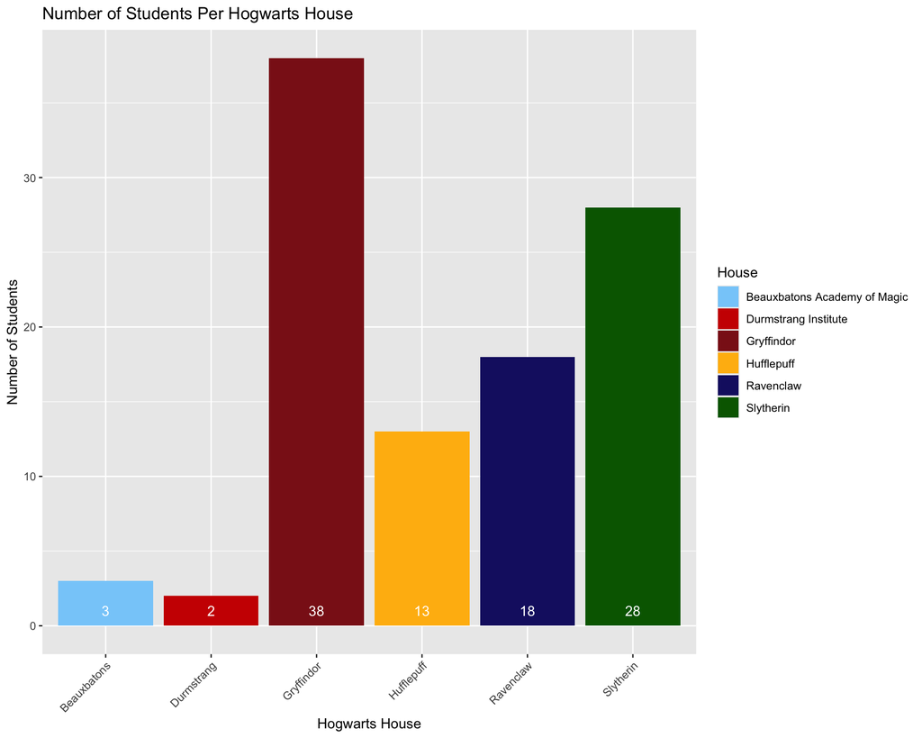